# Taller 6. Redes neuronales recurrentes

Nombres: Manuel Sanchez y Allan Ramirez

Pasos previos

1. Descomprima la carpeta y gu ́ardela en la ubicacíon que desee.
2. Cree un nuevo archivo “main” en su editor de preferencia de Python (en lo posible, utilice

Spyder o Pycharm). Recuerde utilizar el environment en el que usted ya instalo tensorflow.

3. Para cargar los datos puede utilizar las siguientes lıneas:

```python
import os
data_dir = "./Bases/"
fname = os.path.join(data_dir , "jena_climate_2009_2016.csv")
f = open(fname)
data = f.read()
f.close()
lines = data.split("\n")
header = lines [0]. split(",")
lines = lines [1:]
print(header)
print(len(lines))
```

```
['"Date Time"', '"p (mbar)"', '"T (degC)"', '"Tpot (K)"', '"Tdew (degC)"', '"rh (%)"', '"VPmax (mbar)"', '"VPact (mbar)"', '"VPdef (mbar)"', '"sh (g/kg)"', '"H2OC (mmol/mol)"', '"rho (g/m**3)"', '"wv (m/s)"', '"max. wv (m/s)"', '"wd (deg)"']
420451
```

4. Convertiremos los datos en “arrays” de Numpy para acelerar las operaciones:

```python
import numpy as np
float_data = np . zeros (( len ( lines ) , len ( header ) - 1) )
for i , line in enumerate ( lines ):
    values = [ float (x) for x in line . split (",") [1:]]
    float_data [i , :] = values

print(float_data.shape)
```

```
(420451, 14)
```

## Ejercicio 1

Describa preliminarmente los datos que usara en su modelo (utilice estadısticas descriptivas, histogramas, etc.)

```python
import pandas as pd

df = pd.DataFrame(float_data, columns=header[1:])
df.head(10)
```

|  | "p (mbar)" | "T (degC)" | "Tpot (K)" | "Tdew (degC)" | "rh (%)" | "VPmax (mbar)" | "VPact (mbar)" | "VPdef (mbar)" | "sh (g/kg)" | "H2OC (mmol/mol)" | "rho (g/m**3)" | "wv (m/s)" | "max. wv (m/s)" | "wd (deg)" |
| --- | --- | --- | --- | --- | --- | --- | --- | --- | --- | --- | --- | --- | --- | --- |
| 0 | 996.52 | -8.02 | 265.40 | -8.90 | 93.3 | 3.33 | 3.11 | 0.22 | 1.94 | 3.12 | 1307.75 | 1.03 | 1.75 | 152.3 |
| 1 | 996.57 | -8.41 | 265.01 | -9.28 | 93.4 | 3.23 | 3.02 | 0.21 | 1.89 | 3.03 | 1309.80 | 0.72 | 1.50 | 136.1 |
| 2 | 996.53 | -8.51 | 264.91 | -9.31 | 93.9 | 3.21 | 3.01 | 0.20 | 1.88 | 3.02 | 1310.24 | 0.19 | 0.63 | 171.6 |
| 3 | 996.51 | -8.31 | 265.12 | -9.07 | 94.2 | 3.26 | 3.07 | 0.19 | 1.92 | 3.08 | 1309.19 | 0.34 | 0.50 | 198.0 |
| 4 | 996.51 | -8.27 | 265.15 | -9.04 | 94.1 | 3.27 | 3.08 | 0.19 | 1.92 | 3.09 | 1309.00 | 0.32 | 0.63 | 214.3 |
| 5 | 996.50 | -8.05 | 265.38 | -8.78 | 94.4 | 3.33 | 3.14 | 0.19 | 1.96 | 3.15 | 1307.86 | 0.21 | 0.63 | 192.7 |
| 6 | 996.50 | -7.62 | 265.81 | -8.30 | 94.8 | 3.44 | 3.26 | 0.18 | 2.04 | 3.27 | 1305.68 | 0.18 | 0.63 | 166.5 |
| 7 | 996.50 | -7.62 | 265.81 | -8.36 | 94.4 | 3.44 | 3.25 | 0.19 | 2.03 | 3.26 | 1305.69 | 0.19 | 0.50 | 118.6 |
| 8 | 996.50 | -7.91 | 265.52 | -8.73 | 93.8 | 3.36 | 3.15 | 0.21 | 1.97 | 3.16 | 1307.17 | 0.28 | 0.75 | 188.5 |
| 9 | 996.53 | -8.43 | 264.99 | -9.34 | 93.1 | 3.23 | 3.00 | 0.22 | 1.88 | 3.02 | 1309.85 | 0.59 | 0.88 | 185.0 |

```
Medidas resumen:
           "p (mbar)"     "T (degC)"     "Tpot (K)"  "Tdew (degC)"  \
count  420451.000000  420451.000000  420451.000000  420451.000000
mean      989.212508       9.448567     283.491182       4.954011
std         8.359454       8.423685       8.504820       6.730411
min       913.600000     -23.010000     250.600000     -25.010000
25%       984.200000       3.360000     277.430000       0.240000
50%       989.570000       9.410000     283.460000       5.210000
75%       994.720000      15.470000     289.530000      10.070000
max      1015.350000      37.280000     311.340000      23.110000

            "rh (%)"  "VPmax (mbar)"  "VPact (mbar)"  "VPdef (mbar)"  \
count  420451.000000   420451.000000   420451.000000   420451.000000
mean       76.007045       13.575089        9.532524        4.042483
std        16.477126        7.739481        4.183895        4.897270
min        12.950000        0.950000        0.790000        0.000000
25%        65.210000        7.780000        6.210000        0.870000
50%        79.300000       11.820000        8.860000        2.190000
75%        89.400000       17.600000       12.350000        5.300000
max       100.000000       63.770000       28.320000       46.010000

         "sh (g/kg)"  "H2OC (mmol/mol)"  "rho (g/m**3)"     "wv (m/s)"  \
count  420451.000000      420451.000000   420451.000000  420451.000000
mean        6.021630           9.638982     1216.069883       2.130309
std         2.655973           4.235130       39.977065       1.541830
min         0.500000           0.800000     1059.450000       0.000000
25%         3.920000           6.290000     1187.490000       0.990000
50%         5.590000           8.960000     1213.800000       1.760000
75%         7.800000          12.480000     1242.770000       2.860000
max        18.130000          28.820000     1393.540000      14.630000

       "max. wv (m/s)"     "wd (deg)"
count    420451.000000  420451.000000
mean          3.532381     174.726164
std           2.340482      86.675965
min           0.000000       0.000000
25%           1.760000     124.800000
50%           2.960000     198.100000
75%           4.740000     234.100000
max          23.500000     360.000000
```

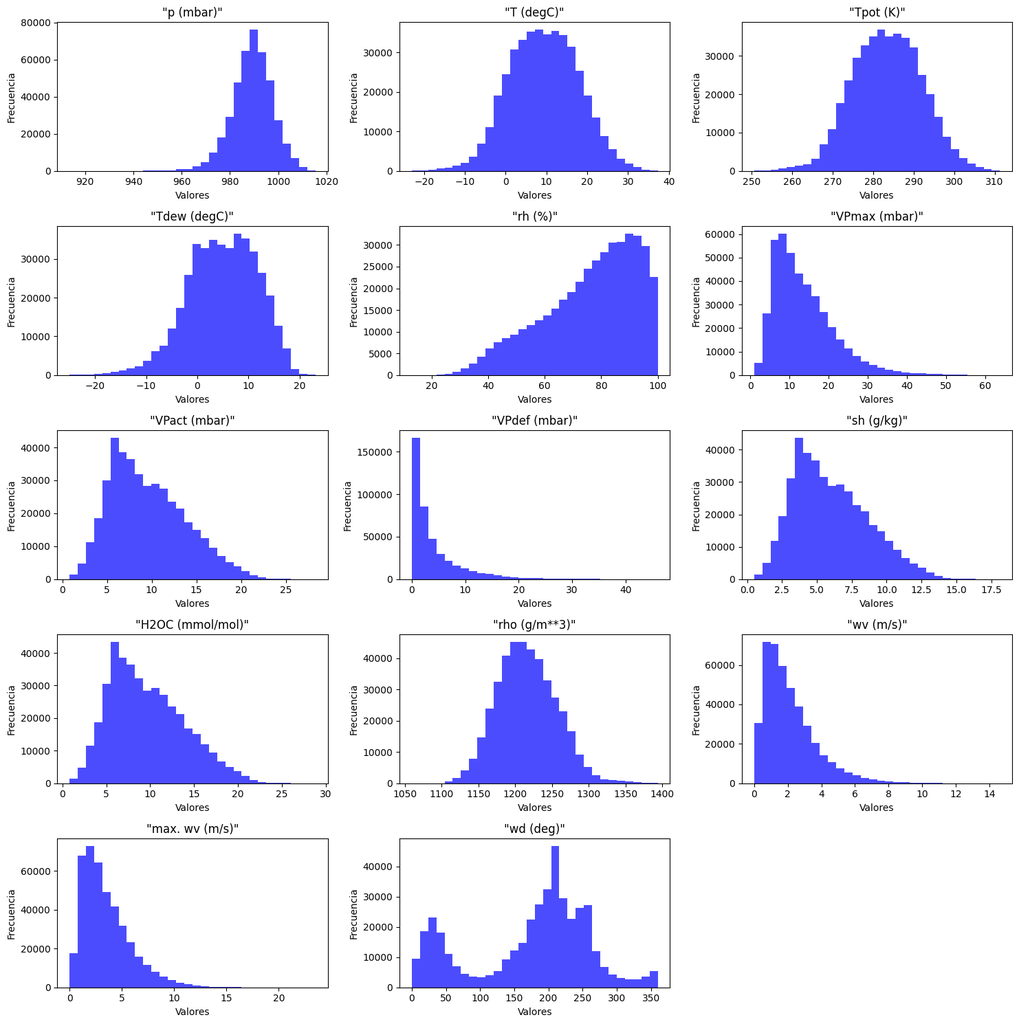

```python
import matplotlib.pyplot as plt

summary_stats = df.describe()
print("Medidas resumen:\n", summary_stats)

fig, axes = plt.subplots(5, 3, figsize=(15, 15))
axes = axes.flatten()  # Aplanar los ejes para iterar fácilmente

for i, column in enumerate(df.columns):
    if i < len(axes):  # Asegurarse de no exceder los ejes disponibles
        axes[i].hist(df[column], bins=30, color='blue', alpha=0.7)
        axes[i].set_title(column)
        axes[i].set_xlabel('Valores')
        axes[i].set_ylabel('Frecuencia')

for i in range(len(df.columns), len(axes)):
    fig.delaxes(axes[i])

plt.tight_layout()
plt.show()
```

Observando tanto las graficas como los histogramas podemos observar los siguientes comportamientos:

Si observamos los rango de los valores podemos ver que tienen diferentes escalas y rangos. Por ejemplo: T (degC) varía aproximadamente de -20 a 40 grados; VPmax (mbar) tiene valores más concentrados en el rango de 0 a 60 mbar y wd (deg) (probablemente dirección del viento) tiene una distribución cíclica en un rango de 0 a 360 grados. Podriamos mencionar que H2OC (mmol/mol) y VPact (mbar) muestran un rango estrecho con alta concentración de valores en su distribución, lo que podría ser indicativo de una variable más homogénea y con menos variabilidad.

Para preprocesar los datos y extraer las secuencias con las que se entrenara la red puede usar la siguiente funcion:

```python
def generator ( data , lookback , delay , min_index , max_index , step =6) :
    if max_index is None :
        max_index = len( data ) - delay - 1
    i = min_index + lookback
    rows = np . arange (i , max_index )
    samples = np . zeros (( len ( rows ) , lookback // step ,data . shape [ -1]) )
    targets = np . zeros (( len ( rows ) ,))
    for j , row in enumerate ( rows ):
        indices = range ( rows [j] - lookback , rows [j ], step )
        samples [j] = data [ indices ]
        targets [j] = data [ rows [ j] + delay ][1]
    return samples , targets
```

La funcion genera los inputs (variable “samples”) junto con los respectivos valores de la variable respuesta, la temperatura (variable “targets”).

Los parametros de la funcion estan descritos de la siguiente forma (Chollet, Francois. Deep learning with Python. Simon and Schuster, 2021 ):

• data — The original array of floating-point data.

• lookback — How many timesteps back the input data should go.

• delay — How many timesteps in the future the target should be.

• min index and max index — Indices in the data array that delimit which timesteps to draw from. This is useful for keeping a segment of the data for validation and another for testing.

• step — The period, in timesteps, at which you sample data. You’ll set it to 6 in order to draw one data point every hour.

## Ejercicio 2

Usando la funcion genere los datos de entrenamiento, validacion y prueba para un valor del lookback deseado. Se recomienda entrenar con mınimo 20, 000 elementos de la base.

```python
# Parámetros
lookback = 288  # Usar datos de las últimas 48 horas
delay = 72      # Predecir 12 horas en el futuro
step = 6        # Un dato cada hora
indice_train = len(float_data)-20000
indice_val = len(float_data)-2000
print(indice_train, indice_val)
```

```
400451 418451
```

En esta celda fijamos los parametros necesarios para crear los datos de entrenamiento, validacion y entrenamiento, por ejemplo usaremos como ventana hacia atras 48 horas atras, mientras que interaremos hacer una prediccion de las siguientes 12 horas, y se tomora un dato una hora que se traduce en 6 pasos, y los indices que se visualizan los puntos de corte para que sepa cual seran los respectivos datos y ahi si usaremos la funcion ´generator´ :

```python
# Generar datos de entrenamiento
X_train, y_train = generator(
    data=float_data,
    lookback=lookback,
    delay=delay,
    min_index=0,            # Desde el inicio del conjunto
    max_index=indice_train,  # Hasta el final del conjunto de entrenamiento
    step=step
)

# Generar datos de validación
X_val, y_val = generator(
    data=float_data,
    lookback=lookback,
    delay=delay,
    min_index=indice_train + 1,  # Desde el primer dato despues final del conjunto de entrenamiento
    max_index=indice_val,       # Hasta el final del conjunto de validación
    step=step
)

# Generar datos de prueba
X_test, y_test = generator(
    data=float_data,
    lookback=lookback,
    delay=delay,
    min_index=indice_val + 1,    # Desde el primer dato despues  final del conjunto de validación
    max_index=None,             # Hasta el final de la base
    step=step
)
```

## Ejercicio 3

Normalice sus datos utilizando la media y la desviacion estandar del conjunto de entrenamiento de cada una de sus variable

```python
# Calcular media y desviación estándar solo usando el conjunto de entrenamiento
train_mean = X_train.mean(axis=0)
train_std = X_train.std(axis=0)


# Normalizar el conjunto de entrenamiento
X_train_norm = (X_train - train_mean) / train_std

# Normalizar el conjunto de validación utilizando la misma media y desviación estándar
X_val_norm = (X_val - train_mean) / train_std

# Normalizar el conjunto de prueba utilizando la misma media y desviación estándar
X_test_norm = (X_test - train_mean) / train_std
```

## Construccion y entrenamiento de la red

Para entrenar la red cargue las librerıas usando: Para construir la primera red puede usar la clase layers.SimpleRNN (las capas recurrentes mas simples).

Puede tomar la siguiente red como ejemplo (la red utiliza el API secuencial, pero recuerde que tambien puede definir la red capa por capa utilizando la funcion “layers” incluyendo al final como parametro la capa anterior):

```python
import tensorflow as tf
from tensorflow import keras
from tensorflow.keras import layers
```

```python
model = keras.Sequential ()
model.add( keras . Input ( shape = ( None , float_data . shape [ -1]) ))
model.add( layers . SimpleRNN (32 , return_sequences = True , activation = "relu") )
model.add ( layers . SimpleRNN (32 , activation = "relu"))
model.add ( layers . Dense (1) )
print(model.summary())
model.compile(
    loss = "mae",
    optimizer = keras . optimizers . Adam ( learning_rate = 0.001) ,
    metrics = ["mse"])
model.fit( X_train_norm , y_train , batch_size = 64 , epochs = 10 , verbose = 2, validation_data =( X_val_norm , y_val ))
model.evaluate( X_test_norm , y_test , batch_size = 64 , verbose = 2)
```

```
Model: "sequential_1"
```

```
┏━━━━━━━━━━━━━━━━━━━━━━━━━━━━━━━━━┳━━━━━━━━━━━━━━━━━━━━━━━━┳━━━━━━━━━━━━━━━┓
┃ Layer (type)                    ┃ Output Shape           ┃       Param # ┃
┡━━━━━━━━━━━━━━━━━━━━━━━━━━━━━━━━━╇━━━━━━━━━━━━━━━━━━━━━━━━╇━━━━━━━━━━━━━━━┩
│ simple_rnn_2 (SimpleRNN)        │ (None, None, 32)       │         1,504 │
├─────────────────────────────────┼────────────────────────┼───────────────┤
│ simple_rnn_3 (SimpleRNN)        │ (None, 32)             │         2,080 │
├─────────────────────────────────┼────────────────────────┼───────────────┤
│ dense_1 (Dense)                 │ (None, 1)              │            33 │
└─────────────────────────────────┴────────────────────────┴───────────────┘
```

```
 Total params: 3,617 (14.13 KB)
```

```
 Trainable params: 3,617 (14.13 KB)
```

```
 Non-trainable params: 0 (0.00 B)
```

```
None
6253/6253 - 92s - 15ms/step - loss: 2.1991 - mse: 8.4950 - val_loss: 1.8515 - val_mse: 5.5738
6253/6253 - 80s - 13ms/step - loss: 1.9871 - mse: 6.7062 - val_loss: 1.9120 - val_mse: 5.9526
6253/6253 - 75s - 12ms/step - loss: 1.9337 - mse: 6.3865 - val_loss: 1.8546 - val_mse: 5.6517
6253/6253 - 72s - 12ms/step - loss: 1.8982 - mse: 6.1702 - val_loss: 1.8318 - val_mse: 5.5209
6253/6253 - 71s - 11ms/step - loss: 1.8681 - mse: 5.9808 - val_loss: 1.8871 - val_mse: 5.8528
6253/6253 - 78s - 13ms/step - loss: 1.8463 - mse: 5.8568 - val_loss: 1.8571 - val_mse: 5.7242
6253/6253 - 78s - 13ms/step - loss: 1.8295 - mse: 5.7655 - val_loss: 1.8980 - val_mse: 5.7933
6253/6253 - 77s - 12ms/step - loss: 1.8129 - mse: 5.6639 - val_loss: 1.9753 - val_mse: 6.1513
6253/6253 - 85s - 14ms/step - loss: 1.7953 - mse: 5.5648 - val_loss: 1.9304 - val_mse: 6.0094
6253/6253 - 76s - 12ms/step - loss: 1.7807 - mse: 5.4860 - val_loss: 1.8797 - val_mse: 5.8036
26/26 - 0s - 6ms/step - loss: 1.8653 - mse: 5.3345
```

```
[1.8653266429901123, 5.334502696990967]
```

Note la ausencia de funcion de activacion en la ultima capa densa. Esto es tıpico en problemas de regresion. Ademas, en el momento de añadir la primera capa en el “layers.SimpleRNN”, el primer parametro es la cantidad de unidades y el segundo se usa para poder utilizar todos los outputs de cada secuencia en lugar de solo el ultimo (necesario si se van a incluir varias capas recurrentes)

## Ejercicio 4

1. Analice cuidadosamente el codigo de arriba e implementelo en su “main” incorporando lo que haga falta para que pueda correrse de forma correcta.

Arquitectura de la Red Neuronal:

- Capa de Entrada (Input): Esta capa define la forma de la entrada. El parámetro shape=(None, float_data.shape[-1]) indica que la red recibirá datos con un número variable de pasos de tiempo (por eso None), pero con un número fijo de características en cada paso de tiempo
- Primera Capa Recurrente (SimpleRNN): Esta es una capa recurrente que tendra una salida de esta capa tendrá 32 valores por cada paso de tiempo.

return_sequences=True: Esto indica que esta capa devuelve las secuencias completas de salidas, es decir, las salidas para todos los pasos de tiempo, lo cual es necesario porque la siguiente capa SimpleRNN también es una capa recurrente. Y su función de activación ReLU (Rectified Linear Unit) es utilizada aquí.

- Segunda Capa Recurrente (SimpleRNN): Es una capa recurrente que tiene los mismo parametros que la primera capa
- Capa Densa de Salida (Dense): Esta capa densa es la capa de salida. Tiene una sola neurona (1) porque estamos realizando una predicción de un solo valor continuo (por ejemplo, temperatura). No se especifica una función de activación,

Compilación del Modelo (model.compile): El modelo usa el error absoluto medio (MAE) como función de pérdida. Esta red usa el optimizador Adam con una tasa de aprendizaje de 0.001. Adam es un optimizador avanzado que ajusta la tasa de aprendizaje para cada parámetro, y durante el entrenamiento, el modelo también mide el error cuadrático medio (MSE)

2. Experimente con las activaciones. La activaci ́on por defecto de SimpleRNN es “tanh”. Para este ejercicio usaremos dos funciones de activacion para comparar resultados y revisar que red se comporta de mejor manera y las funciones seran Tangente Hiperbolica y Leaky Relu

```python
model_tanh = keras.Sequential ()
model_tanh.add( keras . Input ( shape = ( None , float_data . shape [ -1]) ))
model_tanh.add( layers . SimpleRNN (32 , return_sequences = True , activation = "tanh") )
model_tanh.add ( layers . SimpleRNN (32 , activation = "tanh"))
model_tanh.add ( layers . Dense (1) )
print(model_tanh.summary())
model_tanh.compile(
    loss = "mae",
    optimizer = keras . optimizers . Adam ( learning_rate = 0.001) ,
    metrics = ["mse"])
model_tanh.fit( X_train_norm , y_train , batch_size = 64 , epochs = 10 , verbose = 2, validation_data =( X_val_norm , y_val ))
model_tanh.evaluate( X_test_norm , y_test , batch_size = 64 , verbose = 2)
```

```
Model: "sequential_2"
```

```
┏━━━━━━━━━━━━━━━━━━━━━━━━━━━━━━━━━┳━━━━━━━━━━━━━━━━━━━━━━━━┳━━━━━━━━━━━━━━━┓
┃ Layer (type)                    ┃ Output Shape           ┃       Param # ┃
┡━━━━━━━━━━━━━━━━━━━━━━━━━━━━━━━━━╇━━━━━━━━━━━━━━━━━━━━━━━━╇━━━━━━━━━━━━━━━┩
│ simple_rnn_4 (SimpleRNN)        │ (None, None, 32)       │         1,504 │
├─────────────────────────────────┼────────────────────────┼───────────────┤
│ simple_rnn_5 (SimpleRNN)        │ (None, 32)             │         2,080 │
├─────────────────────────────────┼────────────────────────┼───────────────┤
│ dense_2 (Dense)                 │ (None, 1)              │            33 │
└─────────────────────────────────┴────────────────────────┴───────────────┘
```

```
 Total params: 3,617 (14.13 KB)
```

```
 Trainable params: 3,617 (14.13 KB)
```

```
 Non-trainable params: 0 (0.00 B)
```

```
None
6253/6253 - 91s - 14ms/step - loss: 2.3605 - mse: 10.4026 - val_loss: 1.8467 - val_mse: 5.5730
6253/6253 - 76s - 12ms/step - loss: 2.0391 - mse: 7.0046 - val_loss: 1.9519 - val_mse: 6.1757
6253/6253 - 80s - 13ms/step - loss: 1.9948 - mse: 6.7390 - val_loss: 1.8502 - val_mse: 5.5540
6253/6253 - 79s - 13ms/step - loss: 1.9667 - mse: 6.5771 - val_loss: 1.9250 - val_mse: 5.9981
6253/6253 - 75s - 12ms/step - loss: 1.9477 - mse: 6.4702 - val_loss: 1.8480 - val_mse: 5.5504
6253/6253 - 70s - 11ms/step - loss: 1.9394 - mse: 6.4366 - val_loss: 1.9256 - val_mse: 5.9171
6253/6253 - 71s - 11ms/step - loss: 1.9162 - mse: 6.2918 - val_loss: 1.8674 - val_mse: 5.7373
6253/6253 - 68s - 11ms/step - loss: 1.9054 - mse: 6.2323 - val_loss: 1.8854 - val_mse: 5.7395
6253/6253 - 78s - 12ms/step - loss: 1.8994 - mse: 6.2129 - val_loss: 1.8423 - val_mse: 5.6928
6253/6253 - 81s - 13ms/step - loss: 1.8800 - mse: 6.0909 - val_loss: 1.9890 - val_mse: 6.2881
26/26 - 0s - 5ms/step - loss: 2.2219 - mse: 7.3252
```

```
[2.2218503952026367, 7.325217247009277]
```

```python
from tensorflow.keras.layers import LeakyReLU

model_Leak = keras.Sequential ()
model_Leak.add( keras . Input ( shape = ( None , float_data . shape [ -1]) ))
model_Leak.add( layers . SimpleRNN (32 , return_sequences = True , activation=layers.LeakyReLU(alpha=0.01)))
model_Leak.add ( layers . SimpleRNN (32 , activation=layers.LeakyReLU(alpha=0.01)))
model_Leak.add ( layers . Dense (1) )
print(model_Leak.summary())
model_Leak.compile(
    loss = "mae",
    optimizer = keras . optimizers . Adam ( learning_rate = 0.001) ,
    metrics = ["mse"])
model_Leak.fit( X_train_norm , y_train , batch_size = 64 , epochs = 10 , verbose = 2, validation_data =( X_val_norm , y_val ))
model_Leak.evaluate( X_test_norm , y_test , batch_size = 64 , verbose = 2)
```

[output not shown]

```
Model: "sequential_3"
```

```
┏━━━━━━━━━━━━━━━━━━━━━━━━━━━━━━━━━┳━━━━━━━━━━━━━━━━━━━━━━━━┳━━━━━━━━━━━━━━━┓
┃ Layer (type)                    ┃ Output Shape           ┃       Param # ┃
┡━━━━━━━━━━━━━━━━━━━━━━━━━━━━━━━━━╇━━━━━━━━━━━━━━━━━━━━━━━━╇━━━━━━━━━━━━━━━┩
│ simple_rnn_6 (SimpleRNN)        │ (None, None, 32)       │         1,504 │
├─────────────────────────────────┼────────────────────────┼───────────────┤
│ simple_rnn_7 (SimpleRNN)        │ (None, 32)             │         2,080 │
├─────────────────────────────────┼────────────────────────┼───────────────┤
│ dense_3 (Dense)                 │ (None, 1)              │            33 │
└─────────────────────────────────┴────────────────────────┴───────────────┘
```

```
 Total params: 3,617 (14.13 KB)
```

```
 Trainable params: 3,617 (14.13 KB)
```

```
 Non-trainable params: 0 (0.00 B)
```

```
None
6253/6253 - 76s - 12ms/step - loss: 2.2847 - mse: 9.6356 - val_loss: 1.8532 - val_mse: 5.6074
6253/6253 - 71s - 11ms/step - loss: 2.0270 - mse: 6.9475 - val_loss: 1.9378 - val_mse: 6.2814
6253/6253 - 73s - 12ms/step - loss: 1.9727 - mse: 6.6241 - val_loss: 1.8251 - val_mse: 5.4969
6253/6253 - 82s - 13ms/step - loss: 1.9337 - mse: 6.4039 - val_loss: 1.8521 - val_mse: 5.7713
6253/6253 - 72s - 11ms/step - loss: 1.9093 - mse: 6.2555 - val_loss: 1.8567 - val_mse: 5.6114
6253/6253 - 73s - 12ms/step - loss: 1.8895 - mse: 6.1538 - val_loss: 1.8278 - val_mse: 5.5559
6253/6253 - 71s - 11ms/step - loss: 1.8718 - mse: 6.0464 - val_loss: 1.8213 - val_mse: 5.3842
6253/6253 - 72s - 12ms/step - loss: 1.8556 - mse: 5.9483 - val_loss: 1.8681 - val_mse: 5.6870
6253/6253 - 72s - 12ms/step - loss: 1.8362 - mse: 5.8448 - val_loss: 1.9219 - val_mse: 6.1460
6253/6253 - 74s - 12ms/step - loss: 1.8215 - mse: 5.7482 - val_loss: 1.9333 - val_mse: 6.3049
26/26 - 0s - 5ms/step - loss: 1.8513 - mse: 5.6514
```

```
[1.8512804508209229, 5.651383876800537]
```

[output not shown]

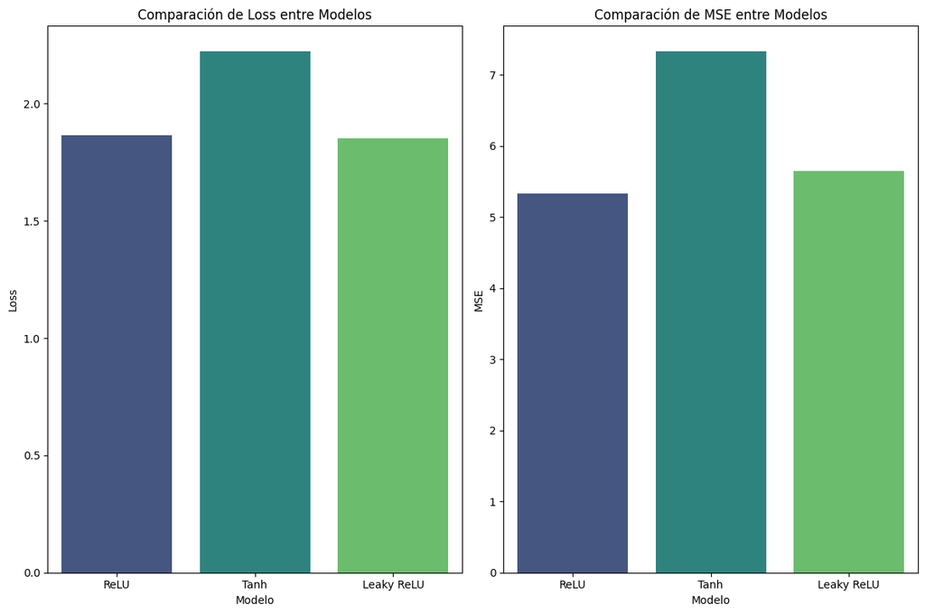

```python
# Extraemos los valores de loss y mse para cada modelo

loss_model = 1.8653266429901123
mse_model = 5.334502696990967

loss_model_tanh = 2.2218503952026367
mse_model_tanh = 7.325217247009277

loss_model_leak = 1.8512804508209229
mse_model_leak = 5.651383876800537

import seaborn as sns
import matplotlib.pyplot as plt
import pandas as pd

# Crear un DataFrame con los valores de loss y mse para cada modelo
data = {
    "Modelo": ["ReLU", "Tanh", "Leaky ReLU"],
    "Loss": [loss_model, loss_model_tanh, loss_model_leak],
    "MSE": [mse_model, mse_model_tanh, mse_model_leak]
}

df = pd.DataFrame(data)

# Crear los gráficos
plt.figure(figsize=(12, 8))

# Barplot para Loss
plt.subplot(1, 2, 1)
sns.barplot(x="Modelo", y="Loss", data=df, palette="viridis")
plt.title("Comparación de Loss entre Modelos")
plt.ylabel("Loss")

# Barplot para MSE
plt.subplot(1, 2, 2)
sns.barplot(x="Modelo", y="MSE", data=df, palette="viridis")
plt.title("Comparación de MSE entre Modelos")
plt.ylabel("MSE")

plt.tight_layout()
plt.show()
```

Observando tenemos las metricas para cada uno de los modelos y podemos identificar que despues de 10 epocas, el mejor modelo que se ajusta es cuando usamos una funcipon de activacion ReLU aunque la Leaky ReLU da resultados bastantes similares por lo que cual quieras de las formas resultan igualmente utiles para realizar predicciones, pero defintivamente la que podriamos descartar en estos momento seria la red que utilizo la funcion tanh ya que tiene los valores de perdida y de mse mas altos.

## Ejercicio 5

1. Investigue sobre las unidades GRU (Gated recurrent unit).

Las unidades GRU (Gated Recurrent Units) son un tipo de capa recurrente en redes neuronales, diseñadas para abordar el problema de desvanecimiento del gradiente en secuencias largas, similar a las LSTM (Long Short-Term Memory), pero con una estructura más simple.

Características clave de las GRU:

- Las GRU utilizan dos puertas principales; La puerta de actualización, esta controla qué cantidad de información del estado anterior se debe mantener y; La puerta de reinicio, esta decide cuánta de la información pasada debe "olvidarse" al generar el nuevo estado.
- Dentro de sus ventajas es en un mejor rendimiento en tareas de procesamiento secuencial, como el análisis de series temporales o procesamiento de lenguaje natural. Y tambien implica en un menor consumo de memoria y computación que las LSTM.
- Usualmente estas unidades GRU se usan frecuentemente en tareas como traducción automática, análisis de sentimientos, predicción de series temporales, y otros problemas que involucran secuencias largas de datos. Son especialmente útiles cuando se necesita un modelo eficiente y rápido para procesar datos secuenciales.
2. y 3. Para implementar las unidades GRU o LSTM puede usar: “layers.GRU” o “layers.LSTM” en lugar de “layers.SimpleRNN”. Y experimente con dichas unidades y describa sus resultados. Comparelos con aquellos obtenidos con las capas layers.SimpleRNN.

```python
model_GRU = keras.Sequential ()
model_GRU.add( keras . Input ( shape = ( None , float_data . shape [ -1]) ))
model_GRU.add( layers.GRU (32 , return_sequences = True , activation = "relu") )
model_GRU.add ( layers.GRU (32 , activation = "relu"))
model_GRU.add ( layers . Dense (1) )
print(model_GRU.summary())
model_GRU.compile(
    loss = "mae",
    optimizer = keras . optimizers . Adam ( learning_rate = 0.001) ,
    metrics = ["mse"])
model_GRU.fit( X_train_norm , y_train , batch_size = 64 , epochs = 10 , verbose = 2, validation_data =( X_val_norm , y_val ))
model_GRU.evaluate( X_test_norm , y_test , batch_size = 64 , verbose = 2)
```

```
Model: "sequential_5"
```

```
┏━━━━━━━━━━━━━━━━━━━━━━━━━━━━━━━━━┳━━━━━━━━━━━━━━━━━━━━━━━━┳━━━━━━━━━━━━━━━┓
┃ Layer (type)                    ┃ Output Shape           ┃       Param # ┃
┡━━━━━━━━━━━━━━━━━━━━━━━━━━━━━━━━━╇━━━━━━━━━━━━━━━━━━━━━━━━╇━━━━━━━━━━━━━━━┩
│ gru_2 (GRU)                     │ (None, None, 32)       │         4,608 │
├─────────────────────────────────┼────────────────────────┼───────────────┤
│ gru_3 (GRU)                     │ (None, 32)             │         6,336 │
├─────────────────────────────────┼────────────────────────┼───────────────┤
│ dense_5 (Dense)                 │ (None, 1)              │            33 │
└─────────────────────────────────┴────────────────────────┴───────────────┘
```

```
 Total params: 10,977 (42.88 KB)
```

```
 Trainable params: 10,977 (42.88 KB)
```

```
 Non-trainable params: 0 (0.00 B)
```

```
None
6253/6253 - 215s - 34ms/step - loss: 2.0937 - mse: 7.9149 - val_loss: 1.7980 - val_mse: 5.4263
6253/6253 - 219s - 35ms/step - loss: 1.8172 - mse: 5.6546 - val_loss: 1.9038 - val_mse: 5.8212
6253/6253 - 216s - 34ms/step - loss: 1.6993 - mse: 5.0190 - val_loss: 1.9956 - val_mse: 6.4921
6253/6253 - 222s - 35ms/step - loss: 1.6084 - mse: 4.5634 - val_loss: 1.9284 - val_mse: 5.9888
6253/6253 - 207s - 33ms/step - loss: 1.5350 - mse: 4.1919 - val_loss: 1.9560 - val_mse: 6.1208
6253/6253 - 215s - 34ms/step - loss: 1.4750 - mse: 3.8970 - val_loss: 2.0392 - val_mse: 6.6323
6253/6253 - 218s - 35ms/step - loss: 1.4225 - mse: 3.6429 - val_loss: 2.0038 - val_mse: 6.4904
6253/6253 - 219s - 35ms/step - loss: 1.3817 - mse: 3.4465 - val_loss: 1.9737 - val_mse: 6.3098
6253/6253 - 212s - 34ms/step - loss: 1.3468 - mse: 3.2828 - val_loss: 2.0382 - val_mse: 6.7402
6253/6253 - 220s - 35ms/step - loss: 1.3154 - mse: 3.1391 - val_loss: 2.1138 - val_mse: 7.3042
26/26 - 0s - 13ms/step - loss: 2.2965 - mse: 7.9490
```

```
[2.2965383529663086, 7.949016571044922]
```

```python
model_LSTM = keras.Sequential ()
model_LSTM.add( keras . Input ( shape = ( None , float_data . shape [ -1]) ))
model_LSTM.add( layers.LSTM (32 , return_sequences = True , activation = "relu") )
model_LSTM.add ( layers.LSTM (32 , activation = "relu"))
model_LSTM.add ( layers . Dense (1) )
print(model_LSTM.summary())
model_LSTM.compile(
    loss = "mae",
    optimizer = keras . optimizers . Adam ( learning_rate = 0.001) ,
    metrics = ["mse"])
model_LSTM.fit( X_train_norm , y_train , batch_size = 64 , epochs = 4 , verbose = 2, validation_data =( X_val_norm , y_val ))
model_LSTM.evaluate( X_test_norm , y_test , batch_size = 64 , verbose = 2)
```

```
Model: "sequential_7"
```

```
┏━━━━━━━━━━━━━━━━━━━━━━━━━━━━━━━━━┳━━━━━━━━━━━━━━━━━━━━━━━━┳━━━━━━━━━━━━━━━┓
┃ Layer (type)                    ┃ Output Shape           ┃       Param # ┃
┡━━━━━━━━━━━━━━━━━━━━━━━━━━━━━━━━━╇━━━━━━━━━━━━━━━━━━━━━━━━╇━━━━━━━━━━━━━━━┩
│ lstm_2 (LSTM)                   │ (None, None, 32)       │         6,016 │
├─────────────────────────────────┼────────────────────────┼───────────────┤
│ lstm_3 (LSTM)                   │ (None, 32)             │         8,320 │
├─────────────────────────────────┼────────────────────────┼───────────────┤
│ dense_7 (Dense)                 │ (None, 1)              │            33 │
└─────────────────────────────────┴────────────────────────┴───────────────┘
```

```
 Total params: 14,369 (56.13 KB)
```

```
 Trainable params: 14,369 (56.13 KB)
```

```
 Non-trainable params: 0 (0.00 B)
```

```
None
6253/6253 - 170s - 27ms/step - loss: 8.0524 - mse: 99905.4844 - val_loss: 2.0817 - val_mse: 7.0005
6253/6253 - 157s - 25ms/step - loss: 2.0641 - mse: 7.1575 - val_loss: 1.9228 - val_mse: 5.7805
6253/6253 - 158s - 25ms/step - loss: 2.0824 - mse: 13.0208 - val_loss: 1.8597 - val_mse: 5.7337
6253/6253 - 157s - 25ms/step - loss: 1.8723 - mse: 5.9941 - val_loss: 1.8407 - val_mse: 5.5184
26/26 - 0s - 8ms/step - loss: 2.1224 - mse: 6.9285
```

```
[2.122392177581787, 6.928492069244385]
```

[output not shown]

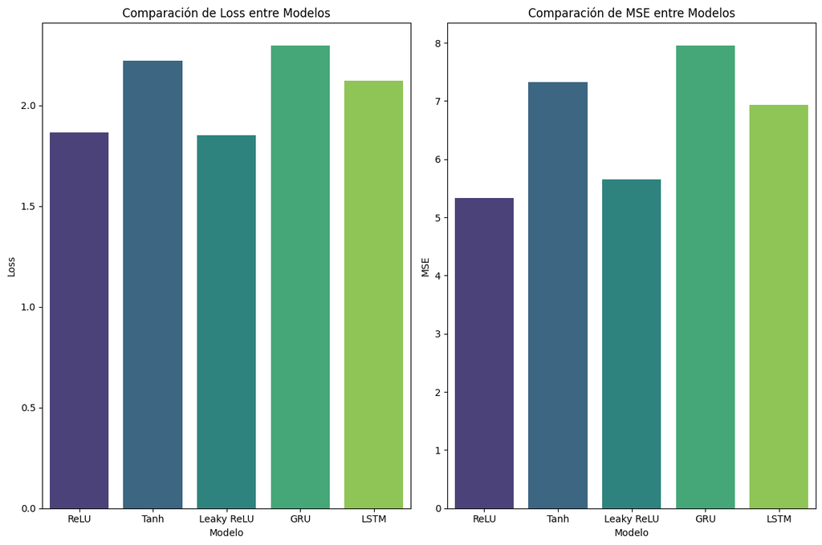

```python
# Extraemos los valores de loss y mse para cada modelo

loss_model_GRU = 2.2965383529663086
mse_model_GRU = 7.949016571044922

loss_model_LSTM = 2.122392177581787
mse_model_LSTM = 6.928492069244385

import seaborn as sns
import matplotlib.pyplot as plt
import pandas as pd

# Crear un DataFrame con los valores de loss y mse para cada modelo
data = {
    "Modelo": ["ReLU", "Tanh", "Leaky ReLU", "GRU", "LSTM"],
    "Loss": [loss_model, loss_model_tanh, loss_model_leak, loss_model_GRU, loss_model_LSTM],
    "MSE": [mse_model, mse_model_tanh, mse_model_leak, mse_model_GRU, mse_model_LSTM]
}

df_1 = pd.DataFrame(data)

# Crear los gráficos
plt.figure(figsize=(12, 8))

# Barplot para Loss
plt.subplot(1, 2, 1)
sns.barplot(x="Modelo", y="Loss", data=df_1, palette="viridis")
plt.title("Comparación de Loss entre Modelos")
plt.ylabel("Loss")

# Barplot para MSE
plt.subplot(1, 2, 2)
sns.barplot(x="Modelo", y="MSE", data=df_1, palette="viridis")
plt.title("Comparación de MSE entre Modelos")
plt.ylabel("MSE")

plt.tight_layout()
plt.show()
```

Si observamos los dos nuevo modelos, podemos observar que el GRU es el que tiene peor desemepeño cuando trabajamos 10 epocas y al usar una red LSTM no damos cuenta que ell rendimiento es mejor que un Tanh si se tuvo que dejar en 4 epoca porque la funcion de perdida y mse crecian exponencialmente mostrando un problema en el entrenamiento, pero se sigue destacando las redes con funciones ReLu y LeaKyReLU, en el siguiente ejercicio revisamos una ultima red para terminar de ver como se comporta

## Ejercicio 6

Para utilizar redes neuronales recurrentes bidireccionales puede utilizar: model.add( layers.Bidirectional(layers.LSTM (256, return_sequences = True)) ) en lugar de las lıneas del c ́odigo original en donde se insertaba la primera capa.

1. y 2. Implemente esta capa bidireccional y compare el desempe ̃no con sus redes anteriores y realice varios entrenamientos de sus redes variando los hiper parametros y las arquitecturas. ¿Cual red ofrece los mejores resultados? (Recuerde utilizar sus conjuntos de validacion y prueba).

```python
model_Bidirecccional = keras.Sequential ()
model_Bidirecccional.add( keras . Input ( shape = ( None , float_data . shape [ -1]) ))
model_Bidirecccional.add( layers.Bidirectional(layers . SimpleRNN (64 , return_sequences = True , activation = "relu")))
model_Bidirecccional.add ( layers . SimpleRNN (64 , activation = "relu"))
model_Bidirecccional.add ( layers . Dense (1) )
print(model_Bidirecccional.summary())
model_Bidirecccional.compile(
    loss = "mae",
    optimizer = keras . optimizers . Adam ( learning_rate = 0.001) ,
    metrics = ["mse"])
model_Bidirecccional.fit( X_train_norm , y_train , batch_size = 64 , epochs = 10 , verbose = 2, validation_data =( X_val_norm , y_val ))
model_Bidirecccional.evaluate( X_test_norm , y_test , batch_size = 64 , verbose = 2)
```

```
Model: "sequential_8"
```

```
┏━━━━━━━━━━━━━━━━━━━━━━━━━━━━━━━━━┳━━━━━━━━━━━━━━━━━━━━━━━━┳━━━━━━━━━━━━━━━┓
┃ Layer (type)                    ┃ Output Shape           ┃       Param # ┃
┡━━━━━━━━━━━━━━━━━━━━━━━━━━━━━━━━━╇━━━━━━━━━━━━━━━━━━━━━━━━╇━━━━━━━━━━━━━━━┩
│ bidirectional (Bidirectional)   │ (None, None, 128)      │        10,112 │
├─────────────────────────────────┼────────────────────────┼───────────────┤
│ simple_rnn_9 (SimpleRNN)        │ (None, 64)             │        12,352 │
├─────────────────────────────────┼────────────────────────┼───────────────┤
│ dense_8 (Dense)                 │ (None, 1)              │            65 │
└─────────────────────────────────┴────────────────────────┴───────────────┘
```

```
 Total params: 22,529 (88.00 KB)
```

```
 Trainable params: 22,529 (88.00 KB)
```

```
 Non-trainable params: 0 (0.00 B)
```

```
None
6253/6253 - 140s - 22ms/step - loss: 2.0784 - mse: 7.4815 - val_loss: 1.8667 - val_mse: 5.9262
6253/6253 - 135s - 22ms/step - loss: 1.8633 - mse: 5.9611 - val_loss: 1.8588 - val_mse: 5.8069
6253/6253 - 134s - 21ms/step - loss: 1.7451 - mse: 5.2949 - val_loss: 1.8839 - val_mse: 5.9315
6253/6253 - 155s - 25ms/step - loss: 1.6524 - mse: 4.7908 - val_loss: 1.8939 - val_mse: 5.9362
6253/6253 - 174s - 28ms/step - loss: 1.5900 - mse: 4.4521 - val_loss: 1.9815 - val_mse: 6.4005
6253/6253 - 154s - 25ms/step - loss: 1.5366 - mse: 4.1776 - val_loss: 1.9738 - val_mse: 6.4016
6253/6253 - 141s - 23ms/step - loss: 1.5016 - mse: 3.9974 - val_loss: 2.0190 - val_mse: 6.6603
6253/6253 - 139s - 22ms/step - loss: 1.4686 - mse: 3.8279 - val_loss: 2.0268 - val_mse: 6.8296
6253/6253 - 138s - 22ms/step - loss: 1.4411 - mse: 3.6967 - val_loss: 1.9970 - val_mse: 6.6432
6253/6253 - 138s - 22ms/step - loss: 1.4094 - mse: 3.5402 - val_loss: 2.0656 - val_mse: 7.0146
26/26 - 0s - 11ms/step - loss: 2.1476 - mse: 6.9871
```

```
[2.1476478576660156, 6.987064838409424]
```

[output not shown]

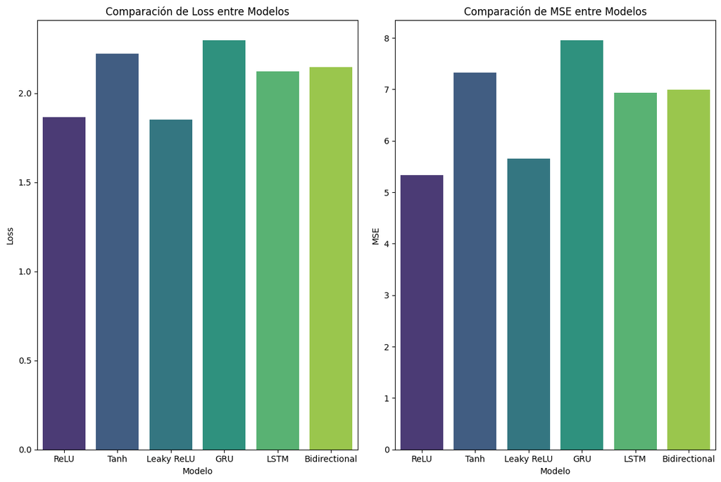

```python
# Extraemos los valores de loss y mse para cada modelo

loss_model_Bi = 2.1476478576660156
mse_model_Bi = 6.987064838409424

import seaborn as sns
import matplotlib.pyplot as plt
import pandas as pd

# Crear un DataFrame con los valores de loss y mse para cada modelo
data = {
    "Modelo": ["ReLU", "Tanh", "Leaky ReLU", "GRU", "LSTM", "Bidirectional"],
    "Loss": [loss_model, loss_model_tanh, loss_model_leak, loss_model_GRU, loss_model_LSTM,loss_model_Bi],
    "MSE": [mse_model, mse_model_tanh, mse_model_leak, mse_model_GRU, mse_model_LSTM,mse_model_Bi]
}

df_2 = pd.DataFrame(data)

# Crear los gráficos
plt.figure(figsize=(12, 8))

# Barplot para Loss
plt.subplot(1, 2, 1)
sns.barplot(x="Modelo", y="Loss", data=df_2, palette="viridis")
plt.title("Comparación de Loss entre Modelos")
plt.ylabel("Loss")

# Barplot para MSE
plt.subplot(1, 2, 2)
sns.barplot(x="Modelo", y="MSE", data=df_2, palette="viridis")
plt.title("Comparación de MSE entre Modelos")
plt.ylabel("MSE")

plt.tight_layout()
plt.show()
```